# 1. Importing Libraries

```python
# install and import necessary libraries.
import matplotlib.pyplot as plt
import seaborn as sns
import re
import numpy as np                                  #for large and multi-dimensional arrays
import pandas as pd                                 #for data manipulation and analysis

import nltk                                         #Natural language processing tool-kit
from wordcloud import WordCloud,STOPWORDS
nltk.download('stopwords')    #download stopwords
nltk.download('punkt')
nltk.download('wordnet')
from nltk.corpus import stopwords                   #Stopwords corpus
from nltk.stem import PorterStemmer                 # Stemmer
from nltk.tokenize import word_tokenize
from nltk.stem.wordnet import WordNetLemmatizer         # Import Lemmatizer.

from sklearn.feature_extraction.text import CountVectorizer          #For Bag of words
from sklearn.feature_extraction.text import TfidfVectorizer          #For TF-IDF

!pip install vaderSentiment    # Install vader sentiment package
!pip install textblob   # Install textblob package
!pip install contractions

import re, string, unicodedata                          # Import Regex, string and unicodedata.
import contractions                                     # Import contractions library.
from bs4 import BeautifulSoup                           # Import BeautifulSoup.

from sklearn.feature_extraction.text import CountVectorizer

from sklearn.ensemble import RandomForestClassifier       # Import Random forest Classifier
from sklearn.metrics import classification_report         # Import Classification report
from sklearn.model_selection import cross_val_score
from sklearn.model_selection import KFold , StratifiedKFold, cross_val_score
from sklearn.metrics import accuracy_score
from sklearn.model_selection import train_test_split
import matplotlib.pyplot as plt
import seaborn as sns
from sklearn.metrics import confusion_matrix
```

# 2. Load Data

```python
from google.colab import drive
drive.mount('/content/drive')
```

```python
tweet_data = pd.read_csv("/content/drive/My Drive/Tweets.csv")
```

```python
tweet_data.head()
```

|  | tweet_id | airline_sentiment | airline_sentiment_confidence | negativereason | negativereason_confidence | airline | airline_sentiment_gold | name | negativereason_gold | retweet_count | text | tweet_coord | tweet_created | tweet_location | user_timezone |
| --- | --- | --- | --- | --- | --- | --- | --- | --- | --- | --- | --- | --- | --- | --- | --- |
| 0 | 570306133677760513 | neutral | 1.0000 | NaN | NaN | Virgin America | NaN | cairdin | NaN | 0 | @VirginAmerica What @dhepburn said. | NaN | 2015-02-24 11:35:52 -0800 | NaN | Eastern Time (US & Canada) |
| 1 | 570301130888122368 | positive | 0.3486 | NaN | 0.0000 | Virgin America | NaN | jnardino | NaN | 0 | @VirginAmerica plus you've added commercials t... | NaN | 2015-02-24 11:15:59 -0800 | NaN | Pacific Time (US & Canada) |
| 2 | 570301083672813571 | neutral | 0.6837 | NaN | NaN | Virgin America | NaN | yvonnalynn | NaN | 0 | @VirginAmerica I didn't today... Must mean I n... | NaN | 2015-02-24 11:15:48 -0800 | Lets Play | Central Time (US & Canada) |
| 3 | 570301031407624196 | negative | 1.0000 | Bad Flight | 0.7033 | Virgin America | NaN | jnardino | NaN | 0 | @VirginAmerica it's really aggressive to blast... | NaN | 2015-02-24 11:15:36 -0800 | NaN | Pacific Time (US & Canada) |
| 4 | 570300817074462722 | negative | 1.0000 | Can't Tell | 1.0000 | Virgin America | NaN | jnardino | NaN | 0 | @VirginAmerica and it's a really big bad thing... | NaN | 2015-02-24 11:14:45 -0800 | NaN | Pacific Time (US & Canada) |

```python
tweet_data.shape
```

```
(14640, 15)
```

```python
tweet_data.isnull().sum(axis=0)
```

```
tweet_id                            0
airline_sentiment                   0
airline_sentiment_confidence        0
negativereason                   5462
negativereason_confidence        4118
airline                             0
airline_sentiment_gold          14600
name                                0
negativereason_gold             14608
retweet_count                       0
text                                0
tweet_coord                     13621
tweet_created                       0
tweet_location                   4733
user_timezone                    4820
dtype: int64
```

### Observations

1. There are 14640 records or tweets across all airlines and customers
2. There are 15 columns
3. Though there are several records which have missing values - non are missing key variables lile airline_sentiment and text. Therefore - we will not drop null values

# 3. EDA

## 3.1 Tweet distibution among airlines

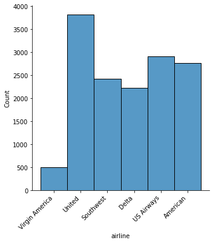

```python
plt.figure(figsize=(10,5))

chart = sns.displot(
    data=tweet_data['airline'],
    x=tweet_data['airline']
)
chart.set_xticklabels(rotation=45, horizontalalignment='right')
```

### Observations

1. United has the most tweets
2. US Airways and American are close second
3. Southwest and Delta are third
4. Virgin has the fewest

## 3.2 Sentiment Distribution

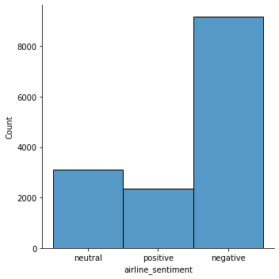

```python
plt.figure(figsize=(10,5))

chart = sns.displot(
    data=tweet_data['airline_sentiment'],
    x=tweet_data['airline_sentiment']
)
```

### Observations

1. Predominantly the tweets are negative in nature.
2. Followed by nuetral and positive

## 3.3 Word Cloud for Positive Reviews

```python
#creating word cloud for positive reviews
positive_reviews=tweet_data[tweet_data['airline_sentiment']=='positive']
words = ' '.join(positive_reviews['text'])
cleaned_word = " ".join([word for word in words.split()])
```

```python
wordcloud = WordCloud(stopwords=STOPWORDS,
                      background_color='black',
                      width=3000,
                      height=2500
                     ).generate(cleaned_word)
```

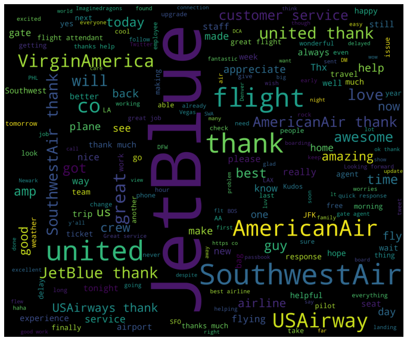

```python
plt.figure(1,figsize=(12, 12))
plt.imshow(wordcloud)
plt.axis('off')
plt.show()
```

## 3.4 Word Cloud for Negative Reviews

```python
#creating word cloud for positive reviews
positive_reviews=tweet_data[tweet_data['airline_sentiment']=='negative']
words = ' '.join(positive_reviews['text'])
cleaned_word = " ".join([word for word in words.split()])
```

```python
wordcloud = WordCloud(stopwords=STOPWORDS,
                      background_color='black',
                      width=3000,
                      height=2500
                     ).generate(cleaned_word)
```

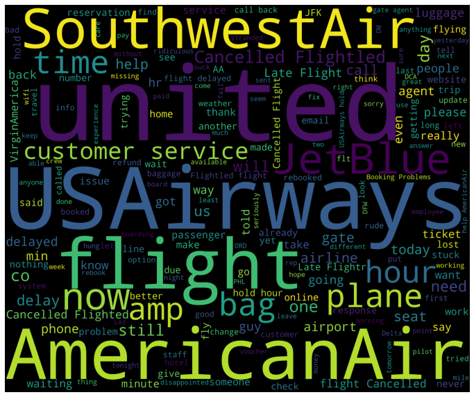

```python
plt.figure(1,figsize=(12, 12))
plt.imshow(wordcloud)
plt.axis('off')
plt.show()
```

### 3.5 Word Cloud for Neutral Reviews

```python
#creating word cloud for positive reviews
positive_reviews=tweet_data[tweet_data['airline_sentiment']=='neutral']
words = ' '.join(positive_reviews['text'])
cleaned_word = " ".join([word for word in words.split()])
```

```python
wordcloud = WordCloud(stopwords=STOPWORDS,
                      background_color='black',
                      width=3000,
                      height=2500
                     ).generate(cleaned_word)
```

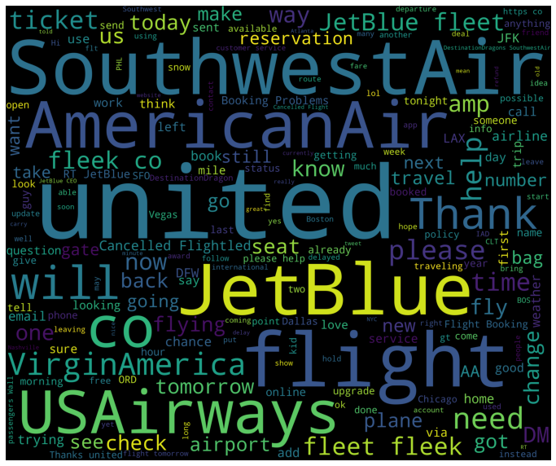

```python
plt.figure(1,figsize=(12, 12))
plt.imshow(wordcloud)
plt.axis('off')
plt.show()
```

# 4 Data Pre-processing

```python
# Save only the text and ailine_sentiment in a new data frame for sentiment analysis
cleaned_tweet_data = tweet_data[['text','airline_sentiment']].copy()
```

```python
cleaned_tweet_data.head()
```

|  | text | airline_sentiment |
| --- | --- | --- |
| 0 | @VirginAmerica What @dhepburn said. | neutral |
| 1 | @VirginAmerica plus you've added commercials t... | positive |
| 2 | @VirginAmerica I didn't today... Must mean I n... | neutral |
| 3 | @VirginAmerica it's really aggressive to blast... | negative |
| 4 | @VirginAmerica and it's a really big bad thing... | negative |

```python
cleaned_tweet_data.shape
```

```
(14640, 2)
```

## 4.1 Text pre-processing

```python
#remove the html tags
def strip_html(text):
    soup = BeautifulSoup(text, "html.parser")
    return soup.get_text()

#expand the contractions
def replace_contractions(text):
    """Replace contractions in string of text"""
    return contractions.fix(text)

#remove the numericals present in the text
def remove_numbers(text):
  text = re.sub(r'\d+', '', text)
  return text

def clean_text(text):
    text = strip_html(text)
    text = replace_contractions(text)
    text = remove_numbers(text)
    return text
```

```python
# Remove HTML tags, contractions and numericals from text
cleaned_tweet_data['text'] = cleaned_tweet_data['text'].apply(lambda x: clean_text(x))
```

```python
# Tokenization of data
cleaned_tweet_data['text'] = cleaned_tweet_data.apply(lambda x: nltk.word_tokenize(x['text']), axis=1)
```

```python
cleaned_tweet_data.head()
```

|  | text | airline_sentiment |
| --- | --- | --- |
| 0 | [@, VirginAmerica, What, @, dhepburn, said, .] | neutral |
| 1 | [@, VirginAmerica, plus, you, have, added, com... | positive |
| 2 | [@, VirginAmerica, I, did, not, today, ..., Mu... | neutral |
| 3 | [@, VirginAmerica, it, is, really, aggressive,... | negative |
| 4 | [@, VirginAmerica, and, it, is, a, really, big... | negative |

```python
# Add airline names to the stopwords
stopwords = stopwords.words('english')
stopwords = list(set(stopwords))  + ['americanair', 'jetblue','southwest', 'united', 'usairways','virginamerica']
lemmatizer = WordNetLemmatizer()
```

```python
#remove the non-ASCII characters
def remove_non_ascii(words):
    """Remove non-ASCII characters from list of tokenized words"""
    new_words = []
    for word in words:
        new_word = unicodedata.normalize('NFKD', word).encode('ascii', 'ignore').decode('utf-8', 'ignore')
        new_words.append(new_word)
    return new_words

# convert all characters to lowercase
def to_lowercase(words):
    """Convert all characters to lowercase from list of tokenized words"""
    new_words = []
    for word in words:
        new_word = word.lower()
        new_words.append(new_word)
    return new_words

# Remove the punctuations
def remove_punctuation(words):
    """Remove punctuation from list of tokenized words"""
    new_words = []
    for word in words:
        new_word = re.sub(r'[^\w\s]', '', word)
        if new_word != '':
            new_words.append(new_word)
    return new_words

# Remove the stop words
def remove_stopwords(words):
   """Remove stop words from list of tokenized words"""
   new_words = []
   for word in words:
       if word not in stopwords:
           new_words.append(word)
   return new_words

# lemmatize the words
def lemmatize_list(words):
    new_words = []
    for word in words:
      new_words.append(lemmatizer.lemmatize(word, pos='v'))
    return new_words
```

```python
def normalize(words):
    words = remove_non_ascii(words)
    words = to_lowercase(words)
    words = remove_punctuation(words)
    words = remove_stopwords(words)
    words = lemmatize_list(words)
    return ' '.join(words)
```

```python
# Remove Non ASCII characters, punctuations, stop words and convert to lower case
cleaned_tweet_data['text'] = cleaned_tweet_data.apply(lambda x: normalize(x['text']), axis=1)
```

```python
cleaned_tweet_data.head()
```

|  | text | airline_sentiment |
| --- | --- | --- |
| 0 | dhepburn say | neutral |
| 1 | plus add commercials experience tacky | positive |
| 2 | today must mean need take another trip | neutral |
| 3 | really aggressive blast obnoxious entertainmen... | negative |
| 4 | really big bad thing | negative |

```python
# Codify positive, neetral and negative sentiment with numerical values
cleaned_tweet_data.loc[(cleaned_tweet_data.airline_sentiment == 'neutral'),'airline_sentiment']='0'
cleaned_tweet_data.loc[(cleaned_tweet_data.airline_sentiment == 'positive'),'airline_sentiment']='1'
cleaned_tweet_data.loc[(cleaned_tweet_data.airline_sentiment == 'negative'),'airline_sentiment']='2'
```

```python
cleaned_tweet_data.head()
```

|  | text | airline_sentiment |
| --- | --- | --- |
| 0 | dhepburn say | 0 |
| 1 | plus add commercials experience tacky | 1 |
| 2 | today must mean need take another trip | 0 |
| 3 | really aggressive blast obnoxious entertainmen... | 2 |
| 4 | really big bad thing | 2 |

# 5 Supervised Learning for Sentiment Analysis

# 5.1 CountVectorizer model

### 5.1.1 Vectorize

```python
# Convert text data in to numbers that models can understand and keep only top 200 feaures
Count_vec = CountVectorizer(max_features=200)
```

```python
data_features = Count_vec.fit_transform(cleaned_tweet_data['text'])
```

```python
data_features = data_features.toarray()
```

```python
data_features.shape
```

```
(14640, 200)
```

```python
X = data_features
X.shape
```

```
(14640, 200)
```

```python
y = cleaned_tweet_data.airline_sentiment
y.shape
```

```
(14640,)
```

### 5.1.2 Split in to Test and Train data

```python
X_train, X_test, y_train, y_test = train_test_split(X, y, test_size=0.25, shuffle=False)
```

### 5.1.3 Build a Random Forest Classifier

```python
# Training the best model and calculating accuracy on test data .
clf = RandomForestClassifier(n_estimators=5)
clf
```

```
RandomForestClassifier(bootstrap=True, ccp_alpha=0.0, class_weight=None,
                       criterion='gini', max_depth=None, max_features='auto',
                       max_leaf_nodes=None, max_samples=None,
                       min_impurity_decrease=0.0, min_impurity_split=None,
                       min_samples_leaf=1, min_samples_split=2,
                       min_weight_fraction_leaf=0.0, n_estimators=5,
                       n_jobs=None, oob_score=False, random_state=None,
                       verbose=0, warm_start=False)
```

```python
clf.fit(X_train, y_train)
clf.score(X_test, y_test)
count_vectorizer_predicted = clf.predict(X_test)
print(classification_report(y_test ,count_vectorizer_predicted ))
print("Accuracy of the model is : ",accuracy_score(y_test,count_vectorizer_predicted))
```

```
              precision    recall  f1-score   support

           0       0.32      0.46      0.38       577
           1       0.53      0.54      0.53       456
           2       0.85      0.77      0.81      2627

    accuracy                           0.69      3660
   macro avg       0.57      0.59      0.57      3660
weighted avg       0.73      0.69      0.71      3660

Accuracy of the model is :  0.6920765027322404
```

#### Observations:

1. The overall performance of the model is not bad for a NLP application.
2. However, there is a significant difference in performance of the model between the different sentiments.
3. Negative sentiments seem to perform better from a moldeing perspective.

# 5.2 Optimized CountVectorizer model (Perf improvements)

### 5.2.1 Improved model

```python
# Finding optimal number of base learners using k-fold CV ->
base_ln = [x for x in range(1, 25)]
# base_ln
```

```python
# K-Fold Cross - validation .
cv_scores = []
for b in base_ln:
   clf = RandomForestClassifier(n_estimators = b)
   scores = cross_val_score(clf, X_train, y_train, cv = 5, scoring = 'accuracy')
   cv_scores.append(scores.mean())
```

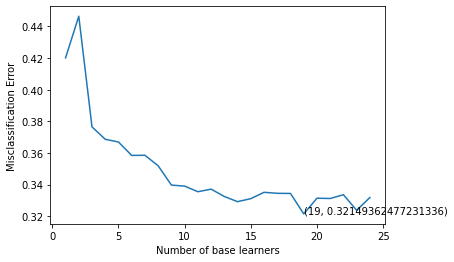

```python
# plotting the error as k increases
error = [1 - x for x in cv_scores]                                 #error corresponds to each nu of estimator
optimal_learners = base_ln[error.index(min(error))]                #Selection of optimal nu of n_estimator corresponds to minimum error.
plt.plot(base_ln, error)                                           #Plot between each nu of estimator and misclassification error
xy = (optimal_learners, min(error))
plt.annotate('(%s, %s)' % xy, xy = xy, textcoords='data')
plt.xlabel("Number of base learners")
plt.ylabel("Misclassification Error")
plt.show()
```

```python
optimal_learners
```

```
19
```

```python
# Training the best model and calculating accuracy on test data .
clf_optimized = RandomForestClassifier(n_estimators = optimal_learners)
clf_optimized.fit(X_train, y_train)
clf_optimized.score(X_test, y_test)
count_vectorizer_predicted_optimized = clf_optimized.predict(X_test)
print(classification_report(y_test ,count_vectorizer_predicted_optimized ))
print("Accuracy of the model is : ",accuracy_score(y_test,count_vectorizer_predicted_optimized))
```

```
              precision    recall  f1-score   support

           0       0.37      0.44      0.40       577
           1       0.58      0.57      0.57       456
           2       0.85      0.82      0.83      2627

    accuracy                           0.73      3660
   macro avg       0.60      0.61      0.60      3660
weighted avg       0.74      0.73      0.73      3660

Accuracy of the model is :  0.7273224043715847
```

### 5.2.2 Top words from word cloud

```
thank,flight,delay,great,http,get,southwestair,love,hold,fly,bag,would,awesome,cancel,please,go,help,hours,make,time,us,need,like,best,service,wait,know,good,seat,still,plane,one,work,customer,try,today,way,airline,take,call,
```

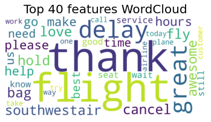

```python
all_features = Count_vec.get_feature_names()              #Instantiate the feature from the vectorizer
top_features=''                                            # Addition of top 40 feature into top_feature after training the model
feat=clf_optimized.feature_importances_
features=np.argsort(feat)[::-1]
for i in features[0:40]:
    top_features+=all_features[i]
    top_features+=','

print(top_features)

print(" ")
print(" ")

from wordcloud import WordCloud
wordcloud = WordCloud(background_color="white",colormap='viridis',width=2000,
                          height=1000).generate(top_features)

# Display the generated image:
plt.imshow(wordcloud, interpolation='bilinear')
plt.figure(1, figsize=(14, 11), frameon='equal')
plt.title('Top 40 features WordCloud', fontsize=20)
plt.axis("off")
plt.show()
```

# 5.3 TDF-IDF model

## 5.3.1 Vectorize

```python
# Vectorize the data from text to numbers
tfidf_vect = TfidfVectorizer(max_features=200)
```

```python
tfdif_data_features = tfidf_vect.fit_transform(cleaned_tweet_data['text'])
```

```python
tfdif_data_features = tfdif_data_features.toarray()
```

```python
tfdif_data_features.shape
```

```
(14640, 200)
```

```python
X_tfdif = tfdif_data_features
X_tfdif.shape
```

```
(14640, 200)
```

```python
y_tfdif = cleaned_tweet_data.airline_sentiment
y_tfdif.shape
```

```
(14640,)
```

### 5.3.2 Split in to Test and Train data

```python
X_train_tfidf, X_test_tfidf, y_train_tfidf, y_test_tfidf = train_test_split(X_tfdif, y_tfdif, test_size=0.25, shuffle=False)
```

### 5.3.3 Build a RandomForest model

```python
# Training the best model and calculating accuracy on test data .
clf_tfidf = RandomForestClassifier(n_estimators=5)
clf_tfidf.fit(X_train, y_train)
clf_tfidf.score(X_test, y_test)
tf_idf_predicted = clf_tfidf.predict(X_test)
print(classification_report(y_test_tfidf , tf_idf_predicted))
print("Accuracy of the model is : ",accuracy_score(y_test,tf_idf_predicted))
```

```
              precision    recall  f1-score   support

           0       0.33      0.46      0.39       577
           1       0.55      0.57      0.56       456
           2       0.86      0.78      0.82      2627

    accuracy                           0.70      3660
   macro avg       0.58      0.60      0.59      3660
weighted avg       0.74      0.70      0.72      3660

Accuracy of the model is :  0.7030054644808743
```

#### Observations

1. The performance of the TF-IDF model is not very different from the bag of words approach.
2. The performance of the model across sentiment types is very similar to the bag of words approach
3. We will try to improve performance by tweaking the optimal number of learners as we did in the last model.

# 5.4 Optimized TDF-IDF model (Perf improvements)

### 5.4.1 Optimized model

```python
# Finding optimal number of base learners using k-fold CV ->
base_ln = [x for x in range(1, 25)]
```

```python
cv_scores = []
for b in base_ln:
    clf_tfidf = RandomForestClassifier(n_estimators = b)
    scores = cross_val_score(clf, X_train_tfidf, y_train_tfidf, cv = 5, scoring = 'accuracy')
    cv_scores.append(scores.mean())
```

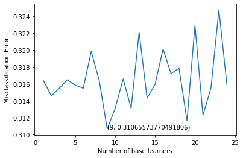

```python
# plotting the error as k increases
error = [1 - x for x in cv_scores]                                 #error corresponds to each nu of estimator
optimal_learners = base_ln[error.index(min(error))]                #Selection of optimal nu of n_estimator corresponds to minimum error.
plt.plot(base_ln, error)                                           #Plot between each nu of estimator and misclassification error
xy = (optimal_learners, min(error))
plt.annotate('(%s, %s)' % xy, xy = xy, textcoords='data')
plt.xlabel("Number of base learners")
plt.ylabel("Misclassification Error")
plt.show()
```

```python
# Training the best model and calculating accuracy on test data .
clf_tfidf_optimized = RandomForestClassifier(n_estimators = 19)
# clf_tfidf = RandomForestClassifier(n_estimators = optimal_learners)
clf_tfidf_optimized.fit(X_train, y_train)
clf_tfidf_optimized.score(X_test, y_test)
tf_idf_predicted_optimized = clf_tfidf_optimized.predict(X_test)
print(classification_report(y_test_tfidf , tf_idf_predicted_optimized))
print("Accuracy of the model is : ",accuracy_score(y_test,tf_idf_predicted_optimized))
```

```
              precision    recall  f1-score   support

           0       0.36      0.43      0.39       577
           1       0.62      0.58      0.60       456
           2       0.85      0.82      0.84      2627

    accuracy                           0.73      3660
   macro avg       0.61      0.61      0.61      3660
weighted avg       0.74      0.73      0.74      3660

Accuracy of the model is :  0.7300546448087432
```

### 5.4.2 Word Cloud and top words

```
thank,flight,http,delay,great,get,southwestair,love,fly,awesome,would,hold,hours,bag,go,cancel,help,need,please,make,hour,us,like,know,best,time,customer,good,one,plane,way,service,still,say,take,look,seat,try,wait,today,
```

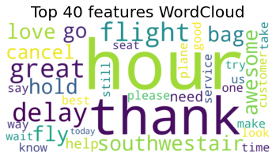

```python
all_features_tfidf = tfidf_vect.get_feature_names()              #Instantiate the feature from the vectorizer
top_features=''                                            # Addition of top 40 feature into top_feature after training the model
feat=clf_tfidf_optimized.feature_importances_
features=np.argsort(feat)[::-1]
for i in features[0:40]:
    top_features+=all_features[i]
    top_features+=','

print(top_features)

print(" ")
print(" ")

from wordcloud import WordCloud
wordcloud = WordCloud(background_color="white",colormap='viridis',width=2000,
                          height=1000).generate(top_features)

# Display the generated image:
plt.imshow(wordcloud, interpolation='bilinear')
plt.figure(1, figsize=(14, 11), frameon='equal')
plt.title('Top 40 features WordCloud', fontsize=20)
plt.axis("off")
plt.show()
```

# 6 Conclusion and recommendation

- Both Countvector and TD-IDF models perform very similarly with minor variations.
- The performance optimizations for both models yielded similar (very modest) improvements in performance.
- It is noteworthy that both models perform better in predicting negative sentiments, followed by positiv and then nuetral.
- The model can certainly be tweaked further with more hyper parameters - but based on the observations - other possible ways to improve model performance are to gather a better sample of data that is more balanced - i.e. have equal number of samples from all sentiments.